# Project_EDA

Maria Martinez

2024-10-22

```r
# Packages and Libraries
library(tidyverse)
library(readr)
library(Ecdat)
```

```r
library(ggplot2)
library(ISLR)
library(GGally)
library(car)
library (scatterplot3d)
library (corrplot)
library(corrgram)
library(stats)
library(dplyr)
library(outliers)
```

```r
# Setting Directory and clean
getwd()
```

```
## [1] "C:/Users/maria/Documents/Georgia-Tech/Data Analytics in Business MGT 6203/PROJECT"
```

```r
rm(list = ls())
```

## Read the data

```r
data <- read.csv("health_data.csv")
head(data)
```

```
##   PatientID Age Gender  BMI SmokingStatus AlcoholConsumption ExerciseFrequency
## 1         1  69   Male 17.3         Never          Regularly            Rarely
## 2         2  32 Female 31.0        Former       Occasionally         Sometimes
## 3         3  89   Male 20.6         Never       Occasionally         Sometimes
## 4         4  78 Female 17.3         Never              Never         Sometimes
## 5         5  38   Male 30.7       Current              Never         Sometimes
## 6         6  41 Female 37.1       Current              Never         Sometimes
##   CholesterolLevel BloodPressure Diabetes HeartDisease PhysicalActivityLevel
## 1              175        157/65       No           No                Medium
## 2              119       173/107      Yes           No                Medium
## 3              226        146/77       No           No                  High
## 4              188       126/104       No           No                Medium
## 5              192       147/111       No           No                  High
## 6              122        166/74       No           No                Medium
##   DietQuality MedicationAdherence AnnualCheckups GeneticRisk HealthcareCost
## 1     Average              Medium              4        0.29          39734
## 2        Poor              Medium              0        0.00          18078
## 3     Average              Medium              1        0.14           4372
## 4     Average              Medium              2        0.53          39936
## 5        Good              Medium              1        0.32          29238
## 6        Poor                 Low              4        0.69          21187
##   Outcome
## 1 At Risk
## 2 Healthy
## 3 Healthy
## 4 At Risk
## 5 Healthy
## 6 At Risk
```

```r
View(head(data,10))
str(data)
```

```
## 'data.frame':    300000 obs. of  18 variables:
##  $ PatientID            : int  1 2 3 4 5 6 7 8 9 10 ...
##  $ Age                  : int  69 32 89 78 38 41 20 39 70 19 ...
##  $ Gender               : chr  "Male" "Female" "Male" "Female" ...
##  $ BMI                  : num  17.3 31 20.6 17.3 30.7 37.1 34.7 19 21.2 31.7 ...
##  $ SmokingStatus        : chr  "Never" "Former" "Never" "Never" ...
##  $ AlcoholConsumption   : chr  "Regularly" "Occasionally" "Occasionally" "Never" ...
##  $ ExerciseFrequency    : chr  "Rarely" "Sometimes" "Sometimes" "Sometimes" ...
##  $ CholesterolLevel     : int  175 119 226 188 192 122 268 107 284 270 ...
##  $ BloodPressure        : chr  "157/65" "173/107" "146/77" "126/104" ...
##  $ Diabetes             : chr  "No" "Yes" "No" "No" ...
##  $ HeartDisease         : chr  "No" "No" "No" "No" ...
##  $ PhysicalActivityLevel: chr  "Medium" "Medium" "High" "Medium" ...
##  $ DietQuality          : chr  "Average" "Poor" "Average" "Average" ...
##  $ MedicationAdherence  : chr  "Medium" "Medium" "Medium" "Medium" ...
##  $ AnnualCheckups       : int  4 0 1 2 1 4 0 0 3 2 ...
##  $ GeneticRisk          : num  0.29 0 0.14 0.53 0.32 0.69 0.85 0.4 0.78 0.67 ...
##  $ HealthcareCost       : int  39734 18078 4372 39936 29238 21187 2426 1278 29968 45239 ...
##  $ Outcome              : chr  "At Risk" "Healthy" "Healthy" "At Risk" ...
```

## Data to variable type and creating the main dummy variables for exploratory step

```r
data$Outcome <- as.factor(data$Outcome)
data$Gender<- as.factor(data$Gender)
data$SmokingStatus <- as.factor(data$SmokingStatus)
data$AlcoholConsumption <- as.factor(data$AlcoholConsumption)
data$ExerciseFrequency <- as.factor(data$ExerciseFrequency)
data$Diabetes <- as.factor(data$Diabetes)
data$HeartDisease <- as.factor(data$HeartDisease)
data$PhysicalActivityLevel <- as.factor(data$PhysicalActivityLevel)
data$DietQuality <- as.factor(data$DietQuality)
data$MedicationAdherence <- as.factor(data$MedicationAdherence)

head(data)
```

```
##   PatientID Age Gender  BMI SmokingStatus AlcoholConsumption ExerciseFrequency
## 1         1  69   Male 17.3         Never          Regularly            Rarely
## 2         2  32 Female 31.0        Former       Occasionally         Sometimes
## 3         3  89   Male 20.6         Never       Occasionally         Sometimes
## 4         4  78 Female 17.3         Never              Never         Sometimes
## 5         5  38   Male 30.7       Current              Never         Sometimes
## 6         6  41 Female 37.1       Current              Never         Sometimes
##   CholesterolLevel BloodPressure Diabetes HeartDisease PhysicalActivityLevel
## 1              175        157/65       No           No                Medium
## 2              119       173/107      Yes           No                Medium
## 3              226        146/77       No           No                  High
## 4              188       126/104       No           No                Medium
## 5              192       147/111       No           No                  High
## 6              122        166/74       No           No                Medium
##   DietQuality MedicationAdherence AnnualCheckups GeneticRisk HealthcareCost
## 1     Average              Medium              4        0.29          39734
## 2        Poor              Medium              0        0.00          18078
## 3     Average              Medium              1        0.14           4372
## 4     Average              Medium              2        0.53          39936
## 5        Good              Medium              1        0.32          29238
## 6        Poor                 Low              4        0.69          21187
##   Outcome
## 1 At Risk
## 2 Healthy
## 3 Healthy
## 4 At Risk
## 5 Healthy
## 6 At Risk
```

```r
data <-data %>% mutate (Critical = ifelse (Outcome == "Critical" , 1,0)) %>% mutate (At_Risk = ifelse (Outcome == "At Risk" , 1,0)) %>% mutate (Healthy = ifelse (Outcome == "Healthy" , 1,0))
view(head(data))
str(data)
```

```
## 'data.frame':    300000 obs. of  21 variables:
##  $ PatientID            : int  1 2 3 4 5 6 7 8 9 10 ...
##  $ Age                  : int  69 32 89 78 38 41 20 39 70 19 ...
##  $ Gender               : Factor w/ 3 levels "Female","Male",..: 2 1 2 1 2 1 1 1 1 1 ...
##  $ BMI                  : num  17.3 31 20.6 17.3 30.7 37.1 34.7 19 21.2 31.7 ...
##  $ SmokingStatus        : Factor w/ 3 levels "Current","Former",..: 3 2 3 3 1 1 1 1 3 2 ...
##  $ AlcoholConsumption   : Factor w/ 3 levels "Never","Occasionally",..: 3 2 2 1 1 1 1 3 1 1 ...
##  $ ExerciseFrequency    : Factor w/ 4 levels "Never","Often",..: 3 4 4 4 4 4 2 2 3 4 ...
##  $ CholesterolLevel     : int  175 119 226 188 192 122 268 107 284 270 ...
##  $ BloodPressure        : chr  "157/65" "173/107" "146/77" "126/104" ...
##  $ Diabetes             : Factor w/ 2 levels "No","Yes": 1 2 1 1 1 1 1 1 1 1 ...
##  $ HeartDisease         : Factor w/ 2 levels "No","Yes": 1 1 1 1 1 1 1 1 1 2 ...
##  $ PhysicalActivityLevel: Factor w/ 3 levels "High","Low","Medium": 3 3 1 3 1 3 2 2 1 3 ...
##  $ DietQuality          : Factor w/ 3 levels "Average","Good",..: 1 3 1 1 2 3 3 1 2 3 ...
##  $ MedicationAdherence  : Factor w/ 3 levels "High","Low","Medium": 3 3 3 3 3 2 3 3 1 3 ...
##  $ AnnualCheckups       : int  4 0 1 2 1 4 0 0 3 2 ...
##  $ GeneticRisk          : num  0.29 0 0.14 0.53 0.32 0.69 0.85 0.4 0.78 0.67 ...
##  $ HealthcareCost       : int  39734 18078 4372 39936 29238 21187 2426 1278 29968 45239 ...
##  $ Outcome              : Factor w/ 3 levels "At Risk","Critical",..: 1 3 3 1 3 1 3 2 1 1 ...
##  $ Critical             : num  0 0 0 0 0 0 0 1 0 0 ...
##  $ At_Risk              : num  1 0 0 1 0 1 0 0 1 1 ...
##  $ Healthy              : num  0 1 1 0 1 0 1 0 0 0 ...
```

## Percentage (Darren Warren)

```r
Table <- data %>% group_by(Outcome) %>%
  summarise( count = n())
table <- as.data.frame(Table)
str(table)
```

```
## 'data.frame':    3 obs. of  2 variables:
##  $ Outcome: Factor w/ 3 levels "At Risk","Critical",..: 1 2 3
##  $ count  : int  90256 29873 179871
```

```r
total = sum(table$count)
table$percentage <- round(table$count/total*100,0)
table
```

```
##    Outcome  count percentage
## 1  At Risk  90256         30
## 2 Critical  29873         10
## 3  Healthy 179871         60
```

## Cholesterol Level in the dataset for Outcome group

```r
TableCh <- data %>% group_by(Outcome) %>%
  summarise( count = n(), n_Cholesterol = mean(CholesterolLevel), min(CholesterolLevel), max(CholesterolLevel))
TableCh
```

```
## # A tibble: 3 × 5
##   Outcome   count n_Cholesterol `min(CholesterolLevel)` `max(CholesterolLevel)`
##   <fct>     <int>         <dbl>                   <int>                   <int>
## 1 At Risk   90256          199.                     100                     299
## 2 Critical  29873          199.                     100                     299
## 3 Healthy  179871          199.                     100                     299
```

## Diabetes in the dataset for Outcome group

```r
TableD <- data %>% group_by(Outcome,Diabetes) %>%
  summarise ( count =n())
TableD
```

```
## # A tibble: 6 × 3
## # Groups:   Outcome [3]
##   Outcome  Diabetes  count
##   <fct>    <fct>     <int>
## 1 At Risk  No        76906
## 2 At Risk  Yes       13350
## 3 Critical No        25400
## 4 Critical Yes        4473
## 5 Healthy  No       152888
## 6 Healthy  Yes       26983
```

## Demographic - Gender in the data set for Outcome Group

```r
TableG <- data %>% group_by(Outcome,Gender) %>%
  summarise ( count =n())
TableG
```

```
## # A tibble: 9 × 3
## # Groups:   Outcome [3]
##   Outcome  Gender count
##   <fct>    <fct>  <int>
## 1 At Risk  Female 44277
## 2 At Risk  Male   44201
## 3 At Risk  Other   1778
## 4 Critical Female 14675
## 5 Critical Male   14634
## 6 Critical Other    564
## 7 Healthy  Female 88112
## 8 Healthy  Male   88075
## 9 Healthy  Other   3684
```

## Demographic - Age in the data set for Outcome Group

```r
TableAg <- data %>% group_by(Outcome,Age) %>%
  summarise ( count =n())
TableAg
```

```
## # A tibble: 216 × 3
## # Groups:   Outcome [3]
##    Outcome   Age count
##    <fct>   <int> <int>
##  1 At Risk    18  1275
##  2 At Risk    19  1267
##  3 At Risk    20  1237
##  4 At Risk    21  1249
##  5 At Risk    22  1321
##  6 At Risk    23  1267
##  7 At Risk    24  1251
##  8 At Risk    25  1291
##  9 At Risk    26  1256
## 10 At Risk    27  1291
## # ℹ 206 more rows
```

## Extract a ramdon sample “A subset from the data set”. Recommend 1000 thousand data points.

```r
sample_1 <- sample_n(data,1000)
head(sample_1)
```

```
##   PatientID Age Gender  BMI SmokingStatus AlcoholConsumption ExerciseFrequency
## 1    205640  27 Female 15.8         Never              Never             Often
## 2    293527  85 Female 29.6        Former       Occasionally         Sometimes
## 3     52683  71 Female 39.7       Current       Occasionally             Never
## 4     43185  37   Male 15.7       Current       Occasionally         Sometimes
## 5     76637  78   Male 32.9        Former              Never            Rarely
## 6    127195  34   Male 35.9         Never              Never         Sometimes
##   CholesterolLevel BloodPressure Diabetes HeartDisease PhysicalActivityLevel
## 1              140        137/73       No           No                   Low
## 2              139       107/105       No           No                Medium
## 3              188        162/64       No           No                   Low
## 4              126       140/107       No           No                Medium
## 5              229        133/88       No           No                Medium
## 6              271        141/79      Yes           No                Medium
##   DietQuality MedicationAdherence AnnualCheckups GeneticRisk HealthcareCost
## 1        Poor              Medium              0        0.03           2501
## 2        Good              Medium              4        0.79          39009
## 3        Poor                 Low              0        0.55          25301
## 4        Good                 Low              3        0.26          36059
## 5     Average              Medium              0        0.85          39610
## 6     Average                High              2        0.15          13448
##    Outcome Critical At_Risk Healthy
## 1  At Risk        0       1       0
## 2 Critical        1       0       0
## 3 Critical        1       0       0
## 4  Healthy        0       0       1
## 5  Healthy        0       0       1
## 6  Healthy        0       0       1
```

## Percentage of Outcome on sample of 1000

```r
Table_1 <- sample_1 %>% group_by(Outcome) %>%
  summarise( count = n())
table_1 <- as.data.frame(Table_1)
str(table_1)
```

```
## 'data.frame':    3 obs. of  2 variables:
##  $ Outcome: Factor w/ 3 levels "At Risk","Critical",..: 1 2 3
##  $ count  : int  296 104 600
```

```r
total_1 = sum(table_1$count)
total_1
```

```
## [1] 1000
```

```r
table_1$percentage <- round((table_1$count/1000) * 100,0)
table_1
```

```
##    Outcome count percentage
## 1  At Risk   296         30
## 2 Critical   104         10
## 3  Healthy   600         60
```

## Cholesterol Level in the sample 1 for Outcome group

```r
TableCh_1 <- sample_1 %>% group_by(Outcome) %>%
  summarise( count = n(), n_Cholesterol = mean(CholesterolLevel), min(CholesterolLevel), max(CholesterolLevel))
TableCh_1
```

```
## # A tibble: 3 × 5
##   Outcome  count n_Cholesterol `min(CholesterolLevel)` `max(CholesterolLevel)`
##   <fct>    <int>         <dbl>                   <int>                   <int>
## 1 At Risk    296          199.                     100                     299
## 2 Critical   104          195.                     103                     298
## 3 Healthy    600          200.                     100                     299
```

## Boxplot graph between Age vs Outcome

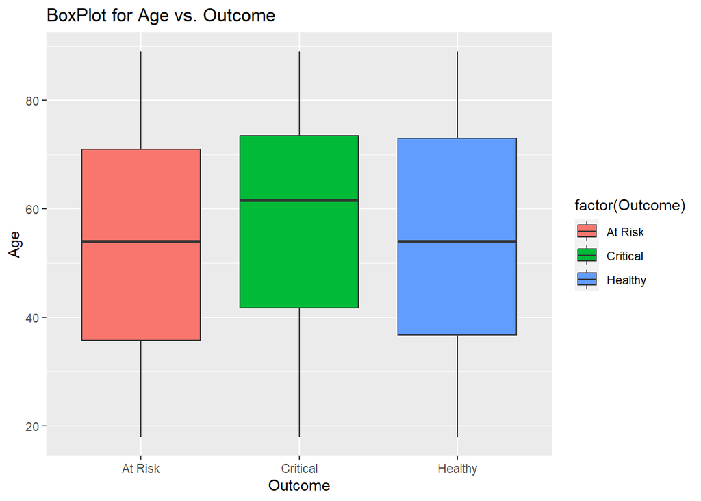

```r
ggplot(data=sample_1, aes(x= factor(Outcome), y = Age, fill= factor(Outcome))) + geom_boxplot() + ggtitle("BoxPlot for Age vs. Outcome") + labs(x="Outcome", y="Age")
```

## Boxplot graph between Age vs Critical

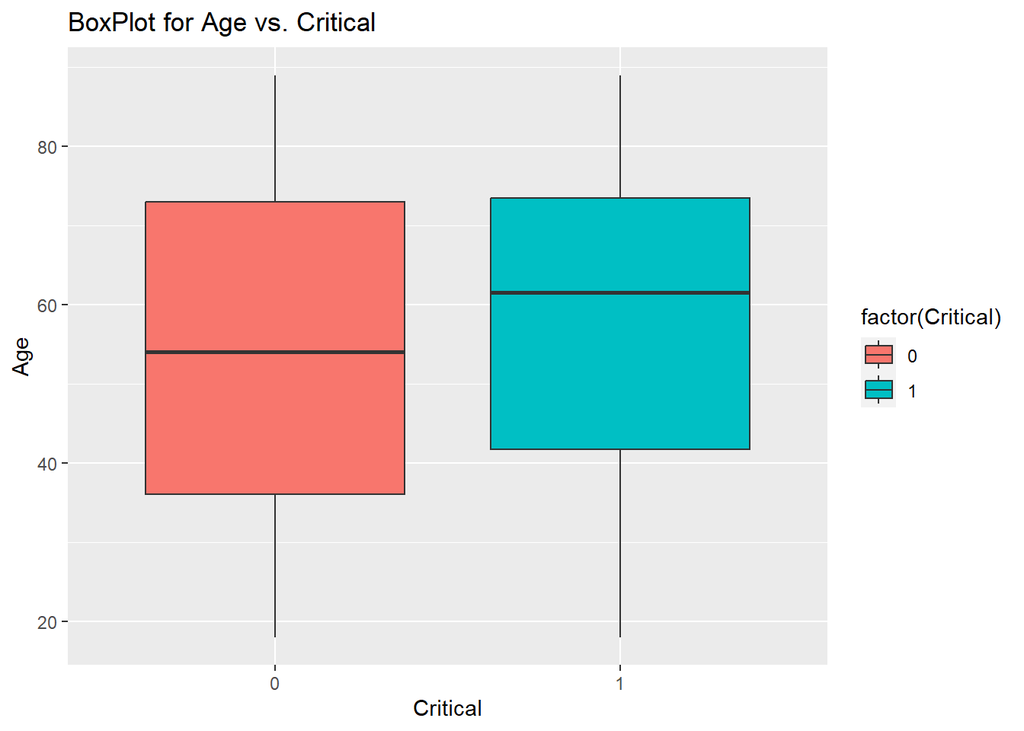

```r
ggplot(data=sample_1, aes(x=factor(Critical), y = Age, fill=factor(Critical))) + geom_boxplot() + ggtitle("BoxPlot for Age vs. Critical") + labs(x="Critical", y="Age")
```

## Boxplot Graph between Cholesterol vs Outcome

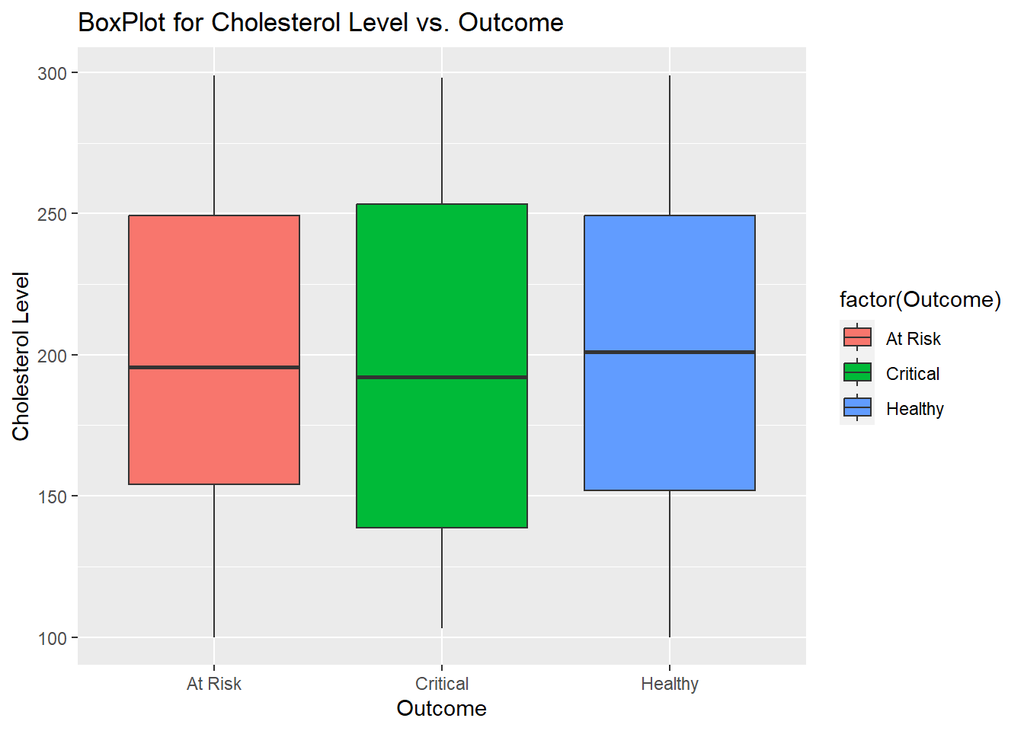

```r
ggplot(data=sample_1, aes(x= factor(Outcome), y = CholesterolLevel, fill= factor(Outcome))) + geom_boxplot() + ggtitle("BoxPlot for Cholesterol Level vs. Outcome") + labs(x="Outcome", y="Cholesterol Level")
```

## Boxplot Graph between Cholesterol vs Critical

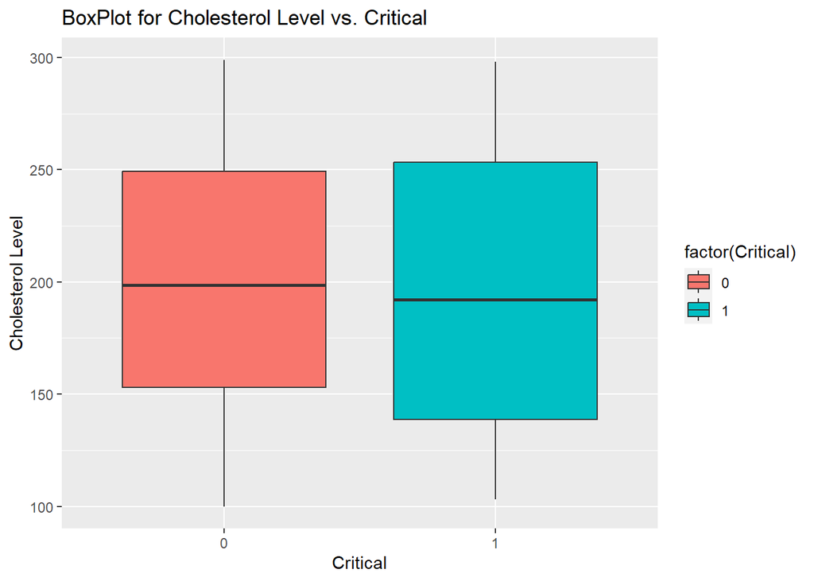

```r
ggplot(data=sample_1, aes(x= factor(Critical), y = CholesterolLevel, fill= factor(Critical))) + geom_boxplot() + ggtitle("BoxPlot for Cholesterol Level vs. Critical") + labs(x="Critical", y="Cholesterol Level")
```

## Boxplot Graph between Genetic Risk vs Outcome

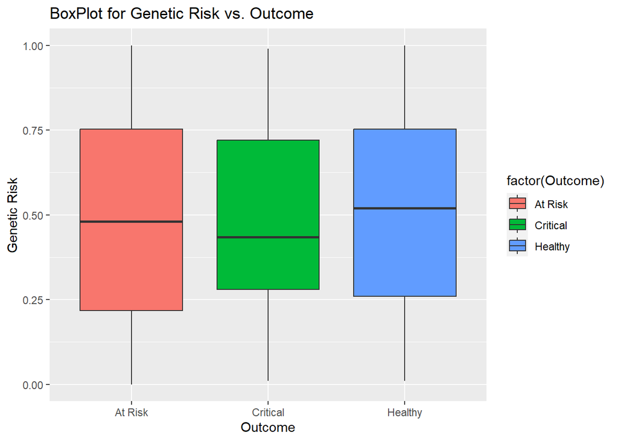

```r
ggplot(data=sample_1, aes(x= factor(Outcome), y = GeneticRisk, fill= factor(Outcome))) + geom_boxplot() + ggtitle("BoxPlot for Genetic Risk vs. Outcome") + labs(x="Outcome", y="Genetic Risk")
```

## Boxplot Graph between Genetic Risk vs Critical

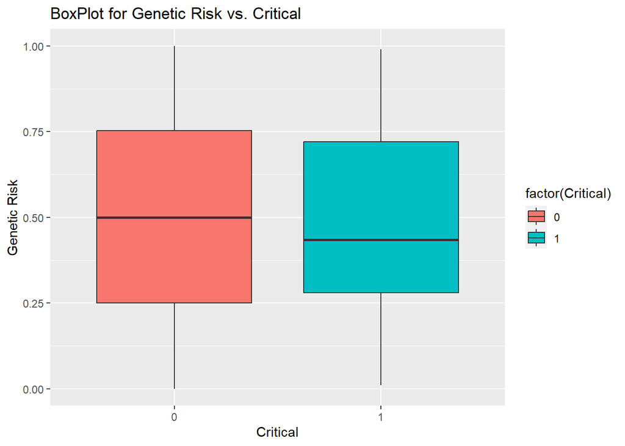

```r
ggplot(data=sample_1, aes(x= factor(Critical), y = GeneticRisk, fill= factor(Critical))) + geom_boxplot() + ggtitle("BoxPlot for Genetic Risk vs. Critical") + labs(x="Critical", y="Genetic Risk")
```

## Extract a ramdon sample “A subset from the data set” (100 data points, also accepted)

```r
sample_2 <- sample_n(data,100)
head(sample_2)
```

```
##   PatientID Age Gender  BMI SmokingStatus AlcoholConsumption ExerciseFrequency
## 1    159478  21   Male 35.4         Never       Occasionally             Often
## 2    133672  70 Female 23.4        Former              Never         Sometimes
## 3     60770  23 Female 37.0        Former          Regularly             Often
## 4    291910  67 Female 37.3         Never              Never            Rarely
## 5    281105  75   Male 33.4       Current       Occasionally         Sometimes
## 6    284665  32   Male 16.5         Never              Never             Never
##   CholesterolLevel BloodPressure Diabetes HeartDisease PhysicalActivityLevel
## 1              193        154/61       No           No                  High
## 2              270       161/102       No           No                  High
## 3              295        153/73      Yes           No                   Low
## 4              134        168/88       No          Yes                Medium
## 5              211        156/67       No           No                   Low
## 6              264        176/90       No           No                Medium
##   DietQuality MedicationAdherence AnnualCheckups GeneticRisk HealthcareCost
## 1     Average              Medium              3        0.08          48402
## 2     Average              Medium              1        0.67          29720
## 3        Good                High              4        0.05          18664
## 4     Average              Medium              0        0.27          48607
## 5     Average              Medium              0        0.29           6745
## 6        Poor                High              0        0.66          40449
##    Outcome Critical At_Risk Healthy
## 1  Healthy        0       0       1
## 2  Healthy        0       0       1
## 3  At Risk        0       1       0
## 4 Critical        1       0       0
## 5  At Risk        0       1       0
## 6  At Risk        0       1       0
```

## Percentage of Outcome on sample of 100

```r
Table_2 <- sample_2 %>% group_by(Outcome) %>%
  summarise( count = n())
table_2 <- as.data.frame(Table_2)
str(table_2)
```

```
## 'data.frame':    3 obs. of  2 variables:
##  $ Outcome: Factor w/ 3 levels "At Risk","Critical",..: 1 2 3
##  $ count  : int  40 7 53
```

```r
total_2 = sum(table_2$count)
total_2
```

```
## [1] 100
```

```r
table_2$percentage <- round((table_2$count/100) * 100,0)
table_2
```

```
##    Outcome count percentage
## 1  At Risk    40         40
## 2 Critical     7          7
## 3  Healthy    53         53
```

# Cholesterol level for Outcome on the sample

```r
Table_2 <- sample_2 %>% group_by(Outcome) %>%
  summarise( count = n(), n_Cholesterol = mean(CholesterolLevel), min(CholesterolLevel), max(CholesterolLevel))
Table_2
```

```
## # A tibble: 3 × 5
##   Outcome  count n_Cholesterol `min(CholesterolLevel)` `max(CholesterolLevel)`
##   <fct>    <int>         <dbl>                   <int>                   <int>
## 1 At Risk     40          195.                     102                     297
## 2 Critical     7          182.                     111                     280
## 3 Healthy     53          195.                     108                     299
```

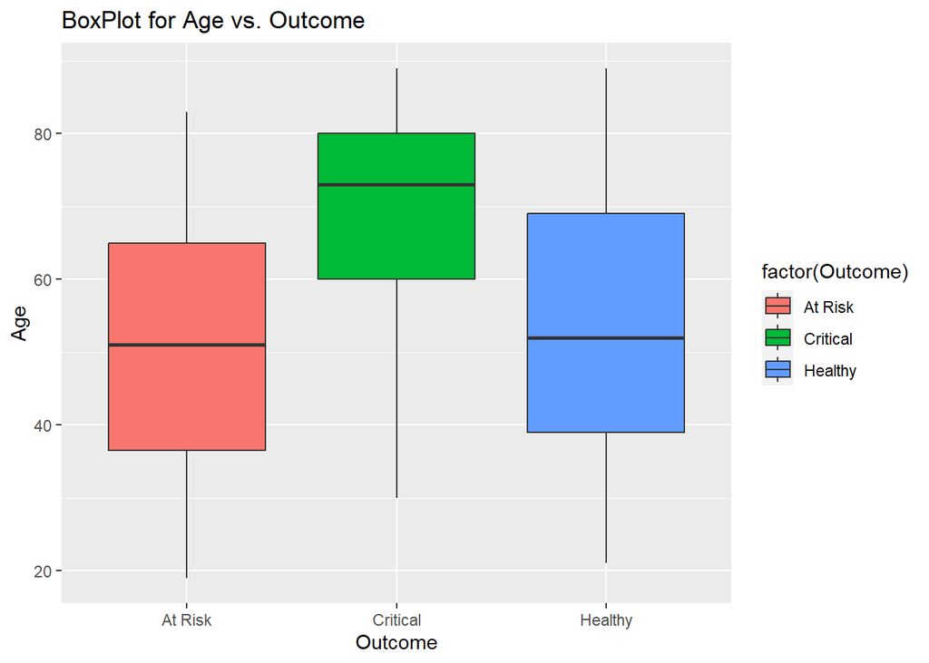

```r
ggplot(data=sample_2, aes(x= factor(Outcome), y = Age, fill= factor(Outcome))) + geom_boxplot() + ggtitle("BoxPlot for Age vs. Outcome") + labs(x="Outcome", y="Age")
```

## BoxPlot for Genetic Risk vs Critical with avg., min and max

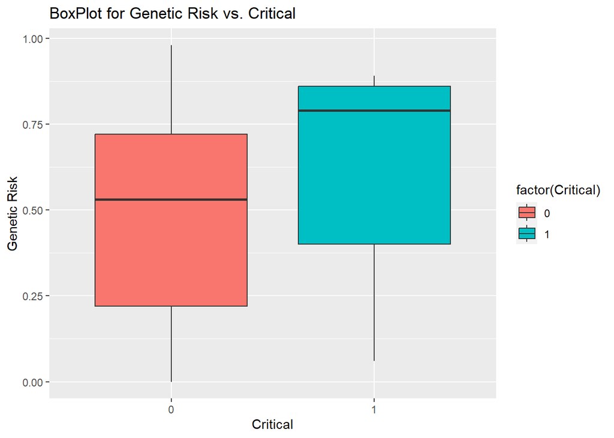

```r
ggplot(data=sample_2, aes(x= factor(Critical), y = GeneticRisk, fill= factor(Critical))) + geom_boxplot() + ggtitle("BoxPlot for Genetic Risk vs. Critical") + labs(x="Critical", y="Genetic Risk")
```

```r
sample_2 %>% group_by(Critical) %>%
  summarise( avg_Genetic_Risk = mean(GeneticRisk), Minim = min(GeneticRisk), Maxi = max(GeneticRisk))
```

```
## # A tibble: 2 × 4
##   Critical avg_Genetic_Risk Minim  Maxi
##      <dbl>            <dbl> <dbl> <dbl>
## 1        0            0.486  0     0.98
## 2        1            0.609  0.06  0.89
```

```r
sample_2 %>% group_by(Critical) %>%
  summarise( avg_Cholesterol = mean(CholesterolLevel), Minim = min(CholesterolLevel), Maxi = max(CholesterolLevel))
```

```
## # A tibble: 2 × 4
##   Critical avg_Cholesterol Minim  Maxi
##      <dbl>           <dbl> <int> <int>
## 1        0            195.   102   299
## 2        1            182.   111   280
```

```r
sample_2 %>% group_by(Critical) %>%
  summarise( count = n())
```

```
## # A tibble: 2 × 2
##   Critical count
##      <dbl> <int>
## 1        0    93
## 2        1     7
```

# BMI vs AGE color Outcome

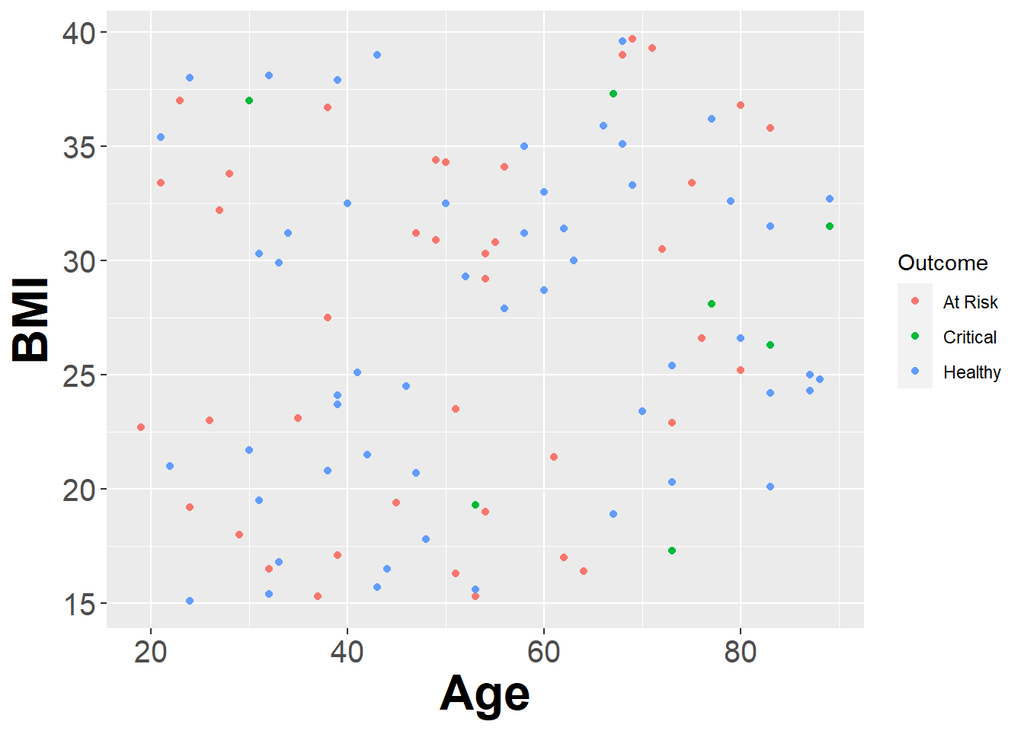

```r
ggplot(data = sample_2) +
  geom_point(mapping = aes(x = Age, y = BMI, color = Outcome)) +
  theme(axis.text.x = element_text(size=15), axis.text.y = element_text(size=15),
  axis.title=element_text(size=24,face="bold"))
```

# BMI vs AGE color Critical

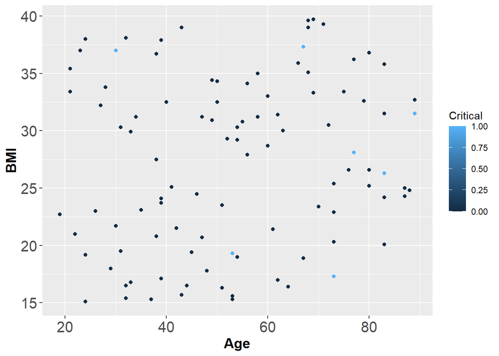

```r
ggplot(data = sample_2) +
  geom_point(mapping = aes(x = Age, y = BMI, color = Critical)) +
  theme(axis.text.x = element_text(size=15), axis.text.y = element_text(size=15),
  axis.title=element_text(size=14,face="bold"))
```

# BMI vs AGE color Critical (Age)

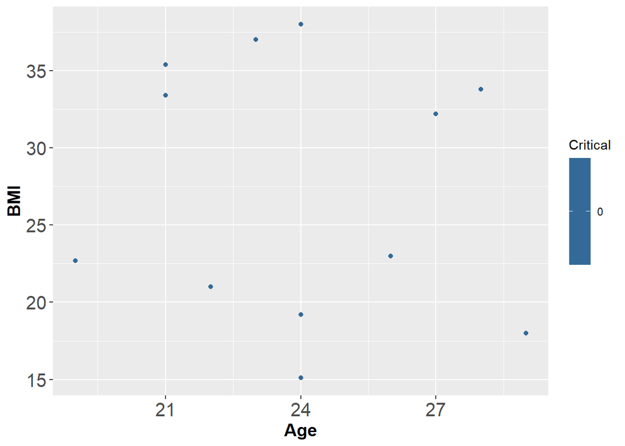

```r
s2_Age <- sample_2 %>% filter (Age < 30)
  ggplot(data = s2_Age) +
  geom_point(mapping = aes(x = Age, y = BMI, color = Critical)) +
  theme(axis.text.x = element_text(size=15), axis.text.y = element_text(size=15),
  axis.title=element_text(size=14,face="bold"))
```

# BMI vs AGE color Critical (Age >70)

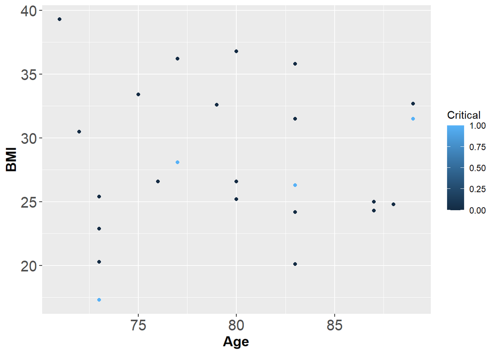

```r
s3_Age <- sample_2 %>% filter (Age > 70)
  ggplot(data = s3_Age) +
  geom_point(mapping = aes(x = Age, y = BMI, color = Critical)) +
  theme(axis.text.x = element_text(size=15), axis.text.y = element_text(size=15),
  axis.title=element_text(size=14,face="bold"))
```

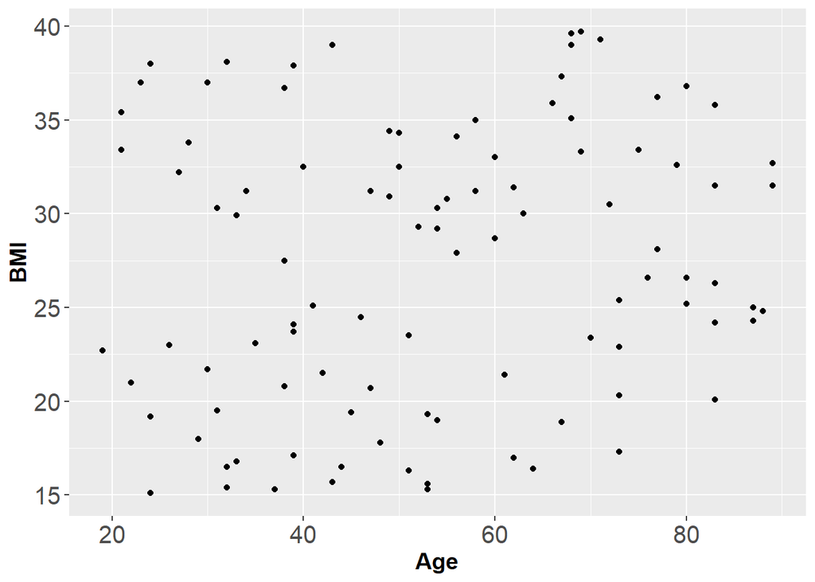

```r
ggplot(sample_2, aes(x=Age, y=BMI)) + geom_point() +
  scale_colour_hue(l=50) +
  theme(axis.text.x = element_text(size=15), axis.text.y = element_text(size=15),
   axis.title=element_text(size=14,face="bold"))
```

## Exploratory Logistic Regression Healthy

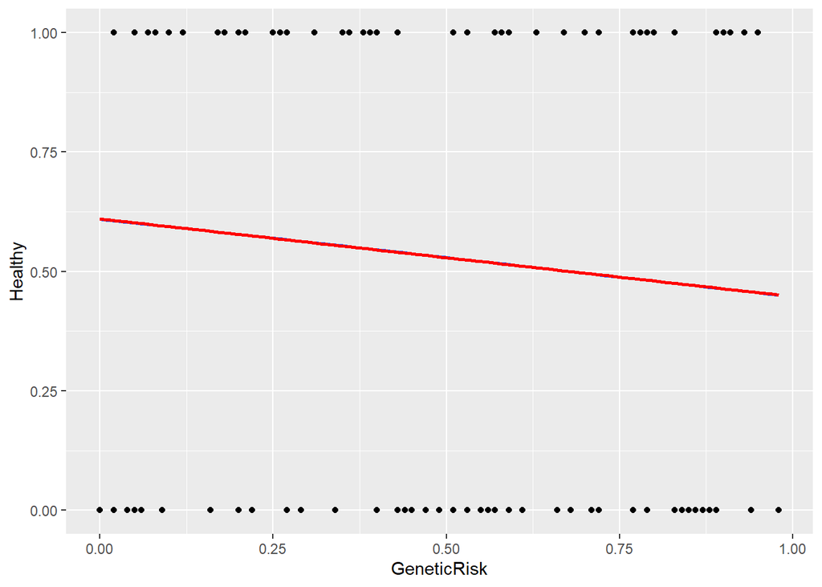

```r
ggplot(sample_2, aes(x=GeneticRisk, y=Healthy)) + geom_point() +
# add logit curve
  stat_smooth(method="glm", method.args=list(family="binomial"), se=FALSE) +
#add the regression line
    geom_smooth(method=lm,  color="red", # Add linear regression lines
              se=FALSE,    # Don't add shaded confidence region
              fullrange=TRUE)
```

## Exploratory Logistic Regression At Risk

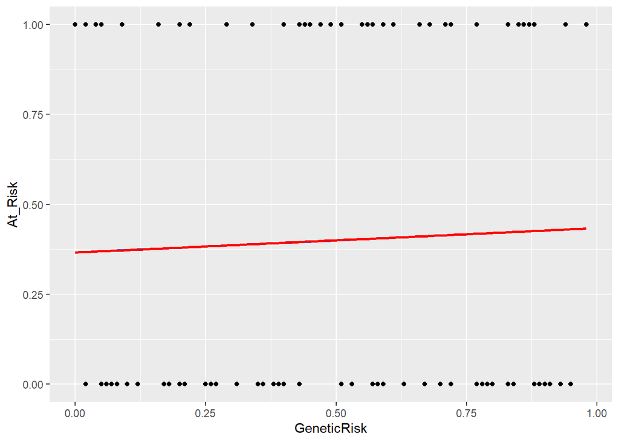

```r
ggplot(sample_2, aes(x=GeneticRisk, y=At_Risk)) + geom_point() +
# add logit curve
  stat_smooth(method="glm", method.args=list(family="binomial"), se=FALSE) +
#add the regression line
    geom_smooth(method=lm,  color="red", # Add linear regression lines
              se=FALSE,    # Don't add shaded confidence region
              fullrange=TRUE)
```

## Exploratory Logistic Regression Critical

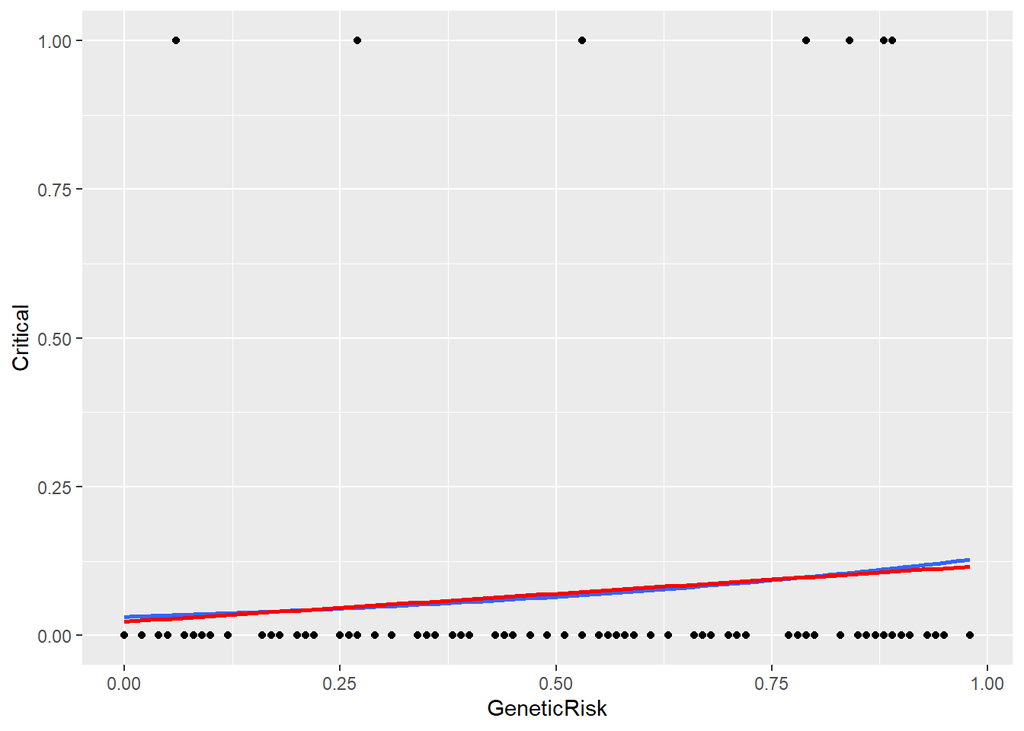

```r
ggplot(sample_2, aes(x=GeneticRisk, y=Critical)) + geom_point() +
# add logit curve
  stat_smooth(method="glm", method.args=list(family="binomial"), se=FALSE) +
#add the regression line
    geom_smooth(method=lm,  color="red", # Add linear regression lines
              se=FALSE,    # Don't add shaded confidence region
              fullrange=TRUE)
```